# 03_results_reprolevels

- Show All Code
- Hide All Code
- View Source

Supporting notebook to compute the reproducibilty scores of the eligible papers. See the **Results** section in the final article.

```r
library(here)
library(tidyverse)
library(dplyr)
library(scales)
library(stringr)
library(gt)
library(ggplot2)
library(ggthemes)
library(patchwork)
#library(svglite)
```

```r
# Adapted from https://github.com/nuest/reproducible-research-at-giscience/blob/master/giscience-reproducibility-assessment.Rmd

criteriaBarplot = function(df, col, main, colour) {
  col <- enquo(col)

  ggplot2::ggplot(df,
                    aes(x=!!col),
                    show.legend = FALSE) +
    ggplot2::geom_bar(fill = colour, color = "black") +
    ggplot2::ggtitle(main) +
    ggplot2::xlab("Level") +
    ggplot2::xlim(udoa_levels) +
    ggplot2::ylab("") +
    ggplot2::scale_y_continuous(breaks = breaks,
                                limits = range(breaks)) +
    ggthemes::theme_tufte(base_size = 10) + ggplot2::theme(axis.ticks.x = element_blank())
}

# Variant to add annotation (percentage) + vertical dotted line to separate high and low levels + (optional text) "HIGH" and "LOW". Note that y position  depeends on the Y-axis scale: 35 for GISciecne barcharts, 45 for AGILE barcharts
criteriaBarplot2 = function(df, col, main, colour, agg_level=F, agg_level_y = 35) {
  col <- enquo(col)

  p <-
    ggplot2::ggplot(df,
                    aes(x=!!col, y = n),
                    show.legend = FALSE) +
    ggplot2::geom_col(fill = colour, color = "black") +
    ggplot2::geom_text(
      aes(label = scales::label_percent(accuracy = 0.1)(p)),
      vjust = -0.5,
      size = 3.5,
      color = "black"
    ) +
    ggplot2::geom_vline(xintercept = 2.5,
                        linetype = "dotted",
                        color = "gray",
                        size = 1) +
    ggplot2::ggtitle(main) +
    ggplot2::xlab("Level") +
    ggplot2::xlim(c("U", "D", "A", "O")) +
    ggplot2::ylab("") +
    ggplot2::scale_y_continuous(breaks = breaks,
                                limits = range(breaks)) +
    ggthemes::theme_tufte(base_size = 10) + ggplot2::theme(axis.ticks.x = element_blank())

    if (agg_level) {
      p <- p +
        ggplot2::annotate("text", x = 2:3, y = agg_level_y, label = c("LOW", "HIGH"), alpha = 0.5)
    }

    return (p)
}
```

```r
udoa_levels <- c("U", "D", "A", "O", NA)

paper_evaluation <-
  readr::read_csv(here::here("data-clean", "all-data.csv"),
                  col_types = readr::cols(
                    conf = readr::col_character(),
                    year = readr::col_integer(),
                    paper = readr::col_character(),
                    title = readr::col_character(),
                    consolidated_cp = readr::col_logical(),
                    consolidated_data = readr::col_factor(levels = udoa_levels),
                    consolidated_methods = readr::col_factor(levels = udoa_levels),
                    consolidated_results = readr::col_factor(levels = udoa_levels),
                    consolidated_ce = readr::col_logical()
                  ),
                  na = c("NA", "Not applicable")) |>
  dplyr::arrange(conf, year)

paper_evaluation <-
  paper_evaluation |>
  dplyr::select(conf, year, paper, title,
                consolidated_cp,
                consolidated_data,
                consolidated_methods,
                consolidated_results,
                consolidated_ce,
                agile_badge) |>
  dplyr::arrange(conf, year)
```

# Introduction

```r
n_papers <- nrow(paper_evaluation)

paper_evaluation_wo_conceptual <- filter(paper_evaluation, consolidated_cp == FALSE)

# Note: we know that NA level has no entries after removing conceptual papers: `paper_evaluation_wo_conceptual`. Drop NA level to avoid an extra column in bar charts
paper_evaluation_wo_conceptual <-
  paper_evaluation_wo_conceptual |>
  dplyr::mutate(consolidated_data = forcats::fct_na_level_to_value(consolidated_data)) |>
  dplyr::mutate(consolidated_methods = forcats::fct_na_level_to_value(consolidated_methods)) |>
  dplyr::mutate(consolidated_results = forcats::fct_na_level_to_value(consolidated_results))

n_papers_wo_conceptual <- nrow(paper_evaluation_wo_conceptual)

paper_evaluation_conceptual <- filter(paper_evaluation, consolidated_cp == TRUE)

n_papers_conceptual <- nrow(paper_evaluation_conceptual)
```

# Assessment of conceptual papers

```r
paper_evaluation_conceptual |>
  dplyr::count(conf) |>
  dplyr::mutate(p = n /sum(n)) |>
  dplyr::filter(conf == "agile") |>
  dplyr::select(n, p) -> agile_conceptual

paper_evaluation_conceptual |>
  dplyr::count(conf) |>
  dplyr::mutate(p = n /sum(n)) |>
  dplyr::filter(conf == "giscience") |>
  dplyr::select(n, p) -> giscience_conceptual
```

Out of the 224, **21** were assigned as conceptual papers and they were excluded from the reproducibility analysis. This represents 9.4% of the total papers assessed.

If we look at the distribution of conceptual papers per conference, we find that, 76.2% (16 / 21) corresponds to AGILE conference papers, while the remaining 23.8% corresponds to GIScience conference papers (5 / 21). Since the number of AGILE papers (146) is almost double that of GIScience (78), there are no significant differences in the distribution of conceptual papers between conferences. However, a practical observation during the evaluation process is that theoretically oriented papers that included a short case study to demonstrate the value of the reported theory were more common at GIScience conferences. These types of papers were classified as non-conceptual, as input data, even small datasets for demonstration/validation purpose, was part of the study.

If we look at the distribution of conceptual papers over time, there is no clear pattern in Figure 1; only that the number of conceptual papers in the first two years (2016-2017), four in each year, has not been reached again in the rest of the period.

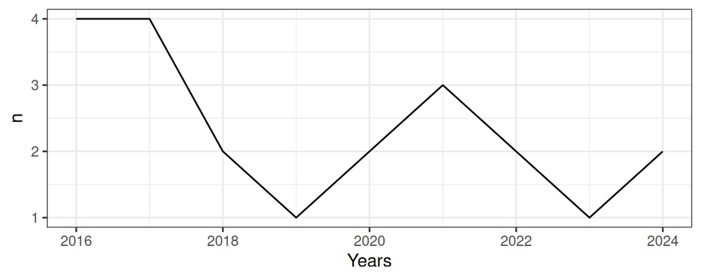

Figure 1: Number of conceptual papers per year, counted for both conferences.

```r
paper_evaluation_conceptual |>
  dplyr::count(year) |>
  ggplot2::ggplot(aes(x=year, y=n),
                    show.legend = FALSE) +
    ggplot2::geom_line(color = "black") +
    ggplot2::xlab("Years") +
    ggplot2::theme_bw()
```

# Reproducibility assessment of non-conceptual papers

There are **203** non-conceptual papers. This represents 90.6% of the total papers assessed. This is the number of papers considered analysed in this section.

## GIScience barplots

```r
papers_giscience <-
  paper_evaluation_wo_conceptual |>
  dplyr::filter (conf =="giscience")

n_papers_giscience <- nrow(papers_giscience)

categoryColumns <- c("consolidated_data",
                     "consolidated_methods",
                     "consolidated_results")

# match the colours to time series plot below
colours <- RColorBrewer::brewer.pal(length(categoryColumns), "Set1")

papers_giscience |>
  dplyr::count(consolidated_data) |>
  dplyr::mutate(p = n /sum(n)) -> papers_giscience_inputdata

papers_giscience |>
  dplyr::count(consolidated_methods) |>
  dplyr::mutate(p = n /sum(n)) -> papers_giscience_methods

papers_giscience |>
  dplyr::count(consolidated_results) |>
  dplyr::mutate(p = n /sum(n)) -> papers_giscience_results
```

Of the total number of non-conceptual papers, GIScience papers represent 36.0% (73).

### Figure: all years (2016, 2018, 2020, 2021, 2023)

```r
papers_giscience_inputdata |>
  gt::gt() |>
  gt::tab_header(
    title = md("Distribution of UDAO levels in *Input Data* criterion"),
    subtitle = stringr::str_glue("GIScience papers (N={n_papers_giscience})")
  ) |>
  gt::fmt_percent(
    columns = p,
    decimals = 1
  ) |>
  gt::cols_label(
    consolidated_data = md("**UDAO**"),
    n = md("**#**"),
    p = md("**%**")
  )
papers_giscience_methods |>
  gt::gt() |>
  gt::tab_header(
    title = md("Distribution of UDAO levels in *Methods* criterion"),
    subtitle = stringr::str_glue("GIScience papers (N={nrow(papers_giscience)})")
  ) |>
  gt::fmt_percent(
    columns = p,
    decimals = 1
  ) |>
  gt::cols_label(
    consolidated_methods = md("**UDAO**"),
    n = md("**#**"),
    p = md("**%**")
  )
papers_giscience_results |>
  gt::gt() |>
  gt::tab_header(
    title = md("Distribution of UDAO levels in *Result* criterion"),
    subtitle = stringr::str_glue("GIScience papers (N={nrow(papers_giscience)})")
  ) |>
  gt::fmt_percent(
    columns = p,
    decimals = 1
  ) |>
  gt::cols_label(
    consolidated_results = md("**UDAO**"),
    n = md("**#**"),
    p = md("**%**")
  )
```

Table 1: GIScience paper assessment

(a) Data

Distribution of UDAO levels in *Input Data* criterion

GIScience papers (N=73)

| **UDAO** | **#** | **%** |
| --- | --- | --- |
| U | 37 | 50.7% |
| D | 20 | 27.4% |
| A | 13 | 17.8% |
| O | 3 | 4.1% |

(b) Methods

Distribution of UDAO levels in *Methods* criterion

GIScience papers (N=73)

| **UDAO** | **#** | **%** |
| --- | --- | --- |
| U | 3 | 4.1% |
| D | 54 | 74.0% |
| A | 13 | 17.8% |
| O | 3 | 4.1% |

(c) Results

Distribution of UDAO levels in *Result* criterion

GIScience papers (N=73)

| **UDAO** | **#** | **%** |
| --- | --- | --- |
| U | 2 | 2.7% |
| D | 64 | 87.7% |
| A | 4 | 5.5% |
| O | 3 | 4.1% |

```r
papers_giscience |>
  dplyr::count(consolidated_methods) |>
  dplyr::slice_max(order_by = n, n = 1) |>
  pull(n) -> n_max_pre

# "60" below is computed manually
breaks <- seq(from = 0, to = 65, by = 5)


plot1 <- criteriaBarplot(papers_giscience, col = consolidated_data, main = "Input", colour = colours[1])

plot2 <- criteriaBarplot(papers_giscience, col = consolidated_methods, main = "Methods", colour = colours[2])

plot3 <- criteriaBarplot(papers_giscience, col = consolidated_results, main = "Results", colour = colours[3])
```

Figure 2 shows the distribution of the reproducibility levels of the GIScience papers for each criterion. As regards the *Input Data* criterion, a bunch of papers reached the highest reproducibility level of Available and **O**pen (3 - 4.1%). Only 13 papers (17.8%) reached level **A**vailable in the Input Data criterion. The number of papers with level **U**ndocumented for Input Data was especially high 37 ((50.7%)). These percentages accurately reflect the same results of a previous study focused on the GIScience conference series for the 2012, 2014, 2016, and 2018 editions (GIScience 2021). The problem we identified at that time remains exactly the same: the large proportion of papers with undocumented input datasets represents a significant barrier to reproduction, as the input data are not only unavailable but also cannot be recreated from the information provided in the paper.

*Methods* and *Results* criteria show a similar distribution (see Figure 2). Indeed, 54 publications (74.0%) for methods and 64 (87.7%) for results have the level Documented. In this sense, most of the assessed papers fall below the minimum standard for reproduction in the methods and results criteria. All papers except two reached level Documented for the Results criterion, which shows that the peer review worked as expected for almost all papers In other words authors are concerned with making the results understandable to the reviewers, which is not always the case for the other criteria. Again, these results are perfectly in line with what we stated in the previous study for the *Methods* and *Results* criteria.

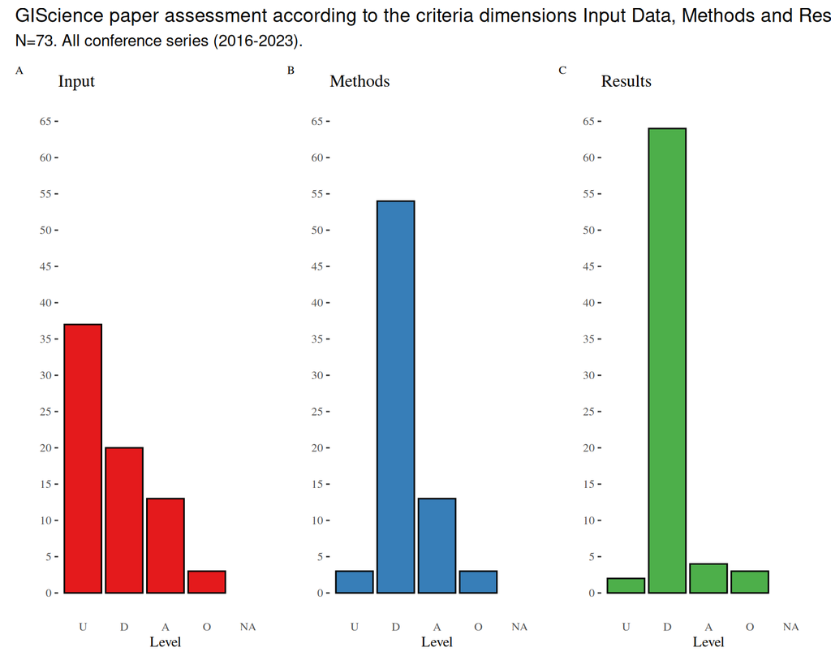

Figure 2: Evaluation of the reproducibility level of GIScience papers for each criterion: Data (A), Methods (B) and Results (C)

```r
(plot1 + plot2 + plot3) +
  plot_layout(widths = c(1,1,1)) +
 plot_annotation(
    title = "GIScience paper assessment according to the criteria dimensions Input Data, Methods and Results.",
    subtitle = stringr::str_glue("N={n_papers_giscience}. All conference series (2016-2023)."),
    tag_levels = 'A') &
  theme(plot.tag = element_text(size = 8))
```

```r
#ggplot2::ggsave(file = here::here("figs", "GIScience_all.svg"),
#       width = 10, height = 7, dpi = 300)
ggplot2::ggsave(file = here::here("figs", "GIScience_all.png"),
       width = 8, height = 6.4, dpi = 300)
```

### Pre-guidelines (2016, 2018)

```r
papers_giscience_pre <-
  papers_giscience |>
  dplyr::filter(year < 2020)

n_papers_giscience_pre = nrow(papers_giscience_pre)

papers_giscience_pre |>
  dplyr::count(consolidated_data) |>
  dplyr::mutate(p = n /sum(n)) -> papers_giscience_data_pre

papers_giscience_pre |>
  dplyr::count(consolidated_methods) |>
  dplyr::mutate(p = n /sum(n)) -> papers_giscience_methods_pre

papers_giscience_pre |>
  dplyr::count(consolidated_results) |>
  dplyr::mutate(p = n /sum(n)) -> papers_giscience_results_pre
```

```r
papers_giscience_data_pre |>
  gt::gt() |>
  gt::tab_header(
    title = md("Distribution of UDAO levels in *Data* criterion"),
    subtitle = stringr::str_glue("2016 and 2018 GIScience papers (N={n_papers_giscience_pre})")
  ) |>
  gt::fmt_percent(
    columns = p,
    decimals = 1
  ) |>
  gt::cols_label(
    consolidated_data = md("**UDAO**"),
    n = md("**#**"),
    p = md("**%**")
  )
papers_giscience_methods_pre |>
  gt::gt() |>
  gt::tab_header(
    title = md("Distribution of UDAO levels in *Methods* criterion"),
    subtitle = stringr::str_glue("2016 and 2018 GIScience papers (N={n_papers_giscience_pre})")
  ) |>
  gt::fmt_percent(
    columns = p,
    decimals = 1
  ) |>
  gt::cols_label(
    consolidated_methods = md("**UDAO**"),
    n = md("**#**"),
    p = md("**%**")
  )
papers_giscience_results_pre |>
  gt::gt() |>
  gt::tab_header(
    title = md("Distribution of UDAO levels in *Results* criterion"),
    subtitle = stringr::str_glue("2016 and 2018 GIScience papers (N={n_papers_giscience_pre})")
  ) |>
  gt::fmt_percent(
    columns = p,
    decimals = 1
  ) |>
  gt::cols_label(
    consolidated_results = md("**UDAO**"),
    n = md("**#**"),
    p = md("**%**")
  )
```

Table 2: GIScience paper assessment (2016, 2018)

(a) Data

Distribution of UDAO levels in *Data* criterion

2016 and 2018 GIScience papers (N=34)

| **UDAO** | **#** | **%** |
| --- | --- | --- |
| U | 19 | 55.9% |
| D | 8 | 23.5% |
| A | 7 | 20.6% |

(b) Methods

Distribution of UDAO levels in *Methods* criterion

2016 and 2018 GIScience papers (N=34)

| **UDAO** | **#** | **%** |
| --- | --- | --- |
| U | 1 | 2.9% |
| D | 32 | 94.1% |
| A | 1 | 2.9% |

(c) Results

Distribution of UDAO levels in *Results* criterion

2016 and 2018 GIScience papers (N=34)

| **UDAO** | **#** | **%** |
| --- | --- | --- |
| U | 2 | 5.9% |
| D | 32 | 94.1% |

### Post-intervention (2021, 2023)

```r
papers_giscience_post <-
  papers_giscience |>
  dplyr::filter(year > 2020)

n_papers_giscience_post = nrow(papers_giscience_post)

papers_giscience_post |>
  dplyr::count(consolidated_data) |>
  dplyr::mutate(p = n /sum(n)) -> papers_giscience_data_post

papers_giscience_post |>
  dplyr::count(consolidated_methods) |>
  dplyr::mutate(p = n /sum(n)) -> papers_giscience_methods_post

papers_giscience_post |>
  dplyr::count(consolidated_results) |>
  dplyr::mutate(p = n /sum(n)) -> papers_giscience_results_post
```

```r
papers_giscience_data_post |>
  gt::gt() |>
  gt::tab_header(
    title = md("Distribution of UDAO levels in *Data* criterion"),
    subtitle = stringr::str_glue("2021 and 2023 GIScience papers (N={n_papers_giscience_post})")
  ) |>
  gt::fmt_percent(
    columns = p,
    decimals = 1
  ) |>
  gt::cols_label(
    consolidated_data = md("**UDAO**"),
    n = md("**#**"),
    p = md("**%**")
  )
papers_giscience_methods_post |>
  gt::gt() |>
  gt::tab_header(
    title = md("Distribution of UDAO levels in *Methods* criterion"),
    subtitle = stringr::str_glue("2021 and 2023 GIScience papers (N={n_papers_giscience_post})")
  ) |>
  gt::fmt_percent(
    columns = p,
    decimals = 1
  ) |>
  gt::cols_label(
    consolidated_methods = md("**UDAO**"),
    n = md("**#**"),
    p = md("**%**")
  )
papers_giscience_results_post |>
  gt::gt() |>
  gt::tab_header(
    title = md("Distribution of UDAO levels in *Results* criterion"),
    subtitle = stringr::str_glue("2021 and 2023 GIScience papers (N={n_papers_giscience_post})")
  ) |>
  gt::fmt_percent(
    columns = p,
    decimals = 1
  ) |>
  gt::cols_label(
    consolidated_results = md("**UDAO**"),
    n = md("**#**"),
    p = md("**%**")
  )
```

Table 3: GIScience paper assessment (2021, 2023)

(a) Data

Distribution of UDAO levels in *Data* criterion

2021 and 2023 GIScience papers (N=24)

| **UDAO** | **#** | **%** |
| --- | --- | --- |
| U | 12 | 50.0% |
| D | 8 | 33.3% |
| A | 2 | 8.3% |
| O | 2 | 8.3% |

(b) Methods

Distribution of UDAO levels in *Methods* criterion

2021 and 2023 GIScience papers (N=24)

| **UDAO** | **#** | **%** |
| --- | --- | --- |
| U | 1 | 4.2% |
| D | 12 | 50.0% |
| A | 9 | 37.5% |
| O | 2 | 8.3% |

(c) Results

Distribution of UDAO levels in *Results* criterion

2021 and 2023 GIScience papers (N=24)

| **UDAO** | **#** | **%** |
| --- | --- | --- |
| D | 18 | 75.0% |
| A | 4 | 16.7% |
| O | 2 | 8.3% |

### Figure: 2016, 2018 *vs.* 2021, 2023

```r
# "35" below is computed manually
breaks <- seq(from = 0, to = 35, by = 5)


#plot1A <- criteriaBarplot(papers_giscience_pre, col = consolidated_data, main = "Input data", colour = colours[1])
plot1A <- criteriaBarplot2(papers_giscience_data_pre, col = consolidated_data, main = "Data", colour = colours[1], agg_level = T)

#plot2A <- criteriaBarplot(papers_giscience_pre, col = consolidated_methods, main = "Methods, analysis, processing", colour = colours[2])
plot2A <- criteriaBarplot2(papers_giscience_methods_pre, col = consolidated_methods, main = "Methods", colour = colours[2])


#plot3A <- criteriaBarplot(papers_giscience_pre, col = consolidated_results, main = "Results", colour = colours[3])
plot3A <- criteriaBarplot2(papers_giscience_results_pre, col = consolidated_results, main = "Results", colour = colours[3])
```

```r
# "35" below is computed manually
breaks <- seq(from = 0, to = 35, by = 5)


#plot1B <- criteriaBarplot(papers_giscience_post, col = consolidated_data, main = "Input data", colour = colours[1])
plot1B <- criteriaBarplot2(papers_giscience_data_post, col = consolidated_data, main = "Data", colour = colours[1], agg_level = T)

#plot2B <- criteriaBarplot(papers_giscience_post, col = consolidated_methods, main = "Methods, analysis, processing", colour = colours[2])
plot2B <- criteriaBarplot2(papers_giscience_methods_post, col = consolidated_methods, main = "Methods", colour = colours[2])

#plot3B <- criteriaBarplot(papers_giscience_post, col = consolidated_results, main = "Results", colour = colours[3])
plot3B <- criteriaBarplot2(papers_giscience_results_post, col = consolidated_results, main = "Results", colour = colours[3])
```

Figure 3 shows the distribution of reproducibility levels of GIScience papers for each criterion, dividing the conference series into two groups: the 2016 and 2018 editions, and the 2021 and 2023 editions. The total number of GIScience papers after exclusion (conceptual, transition year) is **58**. A trend toward higher reproducibility levels is observed in the 2021 and 2023 editions, which may be partly due to a greater awareness of reproducibility among the research community. However, this shift may also be affected by the indirect impact of the AGILE guidelines, as both conferences share a portion of the contributing authors (GIScience paper).

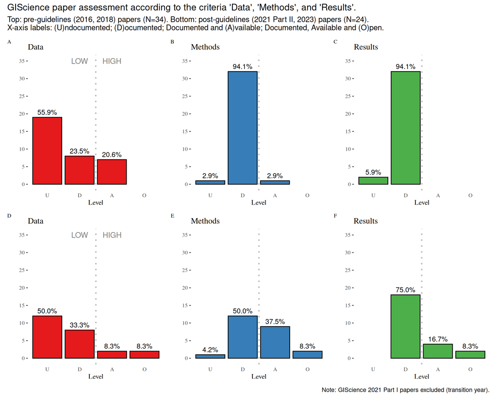

Figure 3: Evaluation of the reproducibility level of GIScience (2016, 2018 vs 2021, 2023) for each criterion: Data (A, D), Methods (B, E) and Results (C, F).

```r
(plot1A + plot2A + plot3A) / (plot1B + plot2B + plot3B) +
  plot_layout(widths = c(1,1,1)) +
  plot_annotation(
    title = "GIScience paper assessment according to the criteria 'Data', 'Methods', and 'Results'.",
    subtitle = stringr::str_glue("Top: pre-guidelines (2016, 2018) papers (N={n_papers_giscience_pre}). Bottom: post-guidelines (2021 Part II, 2023) papers (N={n_papers_giscience_post}).\n X-axis labels: (U)ndocumented; (D)ocumented; Documented and (A)vailable; Documented, Available and (O)pen."),
    caption = "Note: GIScience 2021 Part I papers excluded (transition year).",
    tag_levels = 'A') &
  theme(plot.tag = element_text(size = 8))
```

```r
#ggplot2::ggsave(file = here::here("figs", "AGILE_pre_post.svg"),
#       width = 10, height = 7, dpi = 300)
ggplot2::ggsave(file = here::here("figs", "GIScience_pre_post.png"),
       width = 10, height = 8, dpi = 300)
```

```r
open_giscience_papers <-
  papers_giscience_post |>
  dplyr::filter(consolidated_data=="O" | consolidated_methods=="O" | consolidated_results=="O") |>
  dplyr::select(-conf, -consolidated_cp, -agile_badge)


open_giscience_papers |>
  dplyr::select(-paper) |>
  gt::gt() |>
  gt::tab_header(
    title = md("GIScience papers with highest level of reproducibility on any criterion")
  ) |>
  gt::cols_label(
    year = md("**Year**"),
    title = md("**Title**"),
    consolidated_data = md("**Data**"),
    consolidated_methods = md("**Methods**"),
    consolidated_results = md("**Results**"),
    consolidated_ce = md("**CE**")
  )
```

Table 4: GIScience papers with highest level of reproducibility: Available and Open

GIScience papers with highest level of reproducibility on any criterion

| **Year** | **Title** | **Data** | **Methods** | **Results** | **CE** |
| --- | --- | --- | --- | --- | --- |
| 2021 | Reproducible Research and GIScience: An Evaluation Using GIScience Conference Papers | O | O | O | TRUE |
| 2023 | Genetic Programming for Computationally Efficient Land Use Allocation Optimization | O | O | O | FALSE |

```r
available_giscience_papers <-
  papers_giscience_post |>
  dplyr::filter(consolidated_methods=="A" & consolidated_results=="A") |>
  dplyr::select(-conf, -consolidated_cp, -agile_badge)


available_giscience_papers |>
  dplyr::select(-paper) |>
  gt::gt() |>
  gt::tab_header(
    title = md("GIScience papers with second highest level of reproducibility on Methods and Results criteria")
  ) |>
  gt::cols_label(
    year = md("**Year**"),
    title = md("**Title**"),
    consolidated_data = md("**Data**"),
    consolidated_methods = md("**Methods**"),
    consolidated_results = md("**Results**"),
    consolidated_ce = md("**CE**")
  )
```

Table 5: GIScience papers with second highest level of reproducibility: Available

GIScience papers with second highest level of reproducibility on Methods and Results criteria

| **Year** | **Title** | **Data** | **Methods** | **Results** | **CE** |
| --- | --- | --- | --- | --- | --- |
| 2021 | A Clustering-Based Framework for Individual Travel Behaviour Change Detection | D | A | A | FALSE |
| 2023 | Semi-Supervised Learning from Street-View Images and OpenStreetMap for Automatic Building Height Estimation | D | A | A | FALSE |
| 2023 | Benchmarking Regression Models Under Spatial Heterogeneity | A | A | A | FALSE |

## AGILE barplots

```r
papers_agile <-
  paper_evaluation_wo_conceptual |>
  dplyr::filter (conf =="agile")

n_papers_agile <- nrow(papers_agile)

categoryColumns <- c("consolidated_data",
                     "consolidated_methods",
                     "consolidated_results")

# match the colours to time series plot below
colours <- RColorBrewer::brewer.pal(length(categoryColumns), "Set1")

papers_agile_pre <-
  papers_agile |>
  dplyr::filter(year < 2020)

n_papers_agile_pre = nrow(papers_agile_pre)

papers_agile_pre |>
  dplyr::count(consolidated_data) |>
  dplyr::mutate(p = n /sum(n)) -> papers_agile_data_pre

papers_agile_pre |>
  dplyr::count(consolidated_methods) |>
  dplyr::mutate(p = n /sum(n)) -> papers_agile_methods_pre

papers_agile_pre |>
  dplyr::count(consolidated_results) |>
  dplyr::mutate(p = n /sum(n)) -> papers_agile_results_pre


papers_agile_post <-
  papers_agile |>
  dplyr::filter(year > 2020)

n_papers_agile_post = nrow(papers_agile_post)

papers_agile_post |>
  dplyr::count(consolidated_data) |>
  dplyr::mutate(p = n /sum(n)) -> papers_agile_data_post

papers_agile_post |>
  dplyr::count(consolidated_methods) |>
  dplyr::mutate(p = n /sum(n)) -> papers_agile_methods_post

papers_agile_post |>
  dplyr::count(consolidated_results) |>
  dplyr::mutate(p = n /sum(n)) -> papers_agile_results_post
```

Of the total number of non-conceptual papers, AGILE papers represent 64.0% (130).

### Pre-intervention (2017-2019)

```r
papers_agile_data_pre |>
  gt::gt() |>
  gt::tab_header(
    title = md("Distribution of UDAO levels in *Input Data* criterion"),
    subtitle = stringr::str_glue("AGILE papers pre-intervention (N={n_papers_agile_pre})")
  ) |>
  gt::fmt_percent(
    columns = p,
    decimals = 1
  ) |>
  gt::cols_label(
    consolidated_data = md("**UDAO**"),
    n = md("**#**"),
    p = md("**%**")
  )
papers_agile_methods_pre |>
  gt::gt() |>
  gt::tab_header(
    title = md("Distribution of UDAO levels in *Methods* criterion"),
    subtitle = stringr::str_glue("AGILE papers pre-intervention (N={n_papers_agile_pre})")
  ) |>
  gt::fmt_percent(
    columns = p,
    decimals = 1
  ) |>
  gt::cols_label(
    consolidated_methods = md("**UDAO**"),
    n = md("**#**"),
    p = md("**%**")
  )
papers_agile_results_pre |>
  gt::gt() |>
  gt::tab_header(
    title = md("Distribution of UDAO levels in *Result* criterion"),
    subtitle = stringr::str_glue("AGILE papers pre-intervention (N={n_papers_agile_pre})")
  ) |>
  gt::fmt_percent(
    columns = p,
    decimals = 1
  ) |>
  gt::cols_label(
    consolidated_results = md("**UDAO**"),
    n = md("**#**"),
    p = md("**%**")
  )
```

Table 6: AGILE paper assessment (pre-intervention)

(a) Data

Distribution of UDAO levels in *Input Data* criterion

AGILE papers pre-intervention (N=51)

| **UDAO** | **#** | **%** |
| --- | --- | --- |
| U | 24 | 47.1% |
| D | 16 | 31.4% |
| A | 11 | 21.6% |

(b) Methods

Distribution of UDAO levels in *Methods* criterion

AGILE papers pre-intervention (N=51)

| **UDAO** | **#** | **%** |
| --- | --- | --- |
| U | 5 | 9.8% |
| D | 40 | 78.4% |
| A | 6 | 11.8% |

(c) Results

Distribution of UDAO levels in *Result* criterion

AGILE papers pre-intervention (N=51)

| **UDAO** | **#** | **%** |
| --- | --- | --- |
| U | 3 | 5.9% |
| D | 44 | 86.3% |
| A | 4 | 7.8% |

### Post-intervention (2021-2024)

```r
papers_agile_data_post |>
  gt::gt() |>
  gt::tab_header(
    title = md("Distribution of UDAO levels in *Input Data* criterion"),
    subtitle = stringr::str_glue("AGILE papers post-intervention (N={n_papers_agile_post})")
  ) |>
  gt::fmt_percent(
    columns = p,
    decimals = 1
  ) |>
  gt::cols_label(
    consolidated_data = md("**UDAO**"),
    n = md("**#**"),
    p = md("**%**")
  )
papers_agile_methods_pre |>
  gt::gt() |>
  gt::tab_header(
    title = md("Distribution of UDAO levels in *Methods* criterion"),
    subtitle = stringr::str_glue("AGILE papers post-intervention (N={n_papers_agile_post})")
  ) |>
  gt::fmt_percent(
    columns = p,
    decimals = 1
  ) |>
  gt::cols_label(
    consolidated_methods = md("**UDAO**"),
    n = md("**#**"),
    p = md("**%**")
  )
papers_agile_results_pre |>
  gt::gt() |>
  gt::tab_header(
    title = md("Distribution of UDAO levels in *Result* criterion"),
    subtitle = stringr::str_glue("AGILE papers post-intervention (N={n_papers_agile_post})")
  ) |>
  gt::fmt_percent(
    columns = p,
    decimals = 1
  ) |>
  gt::cols_label(
    consolidated_results = md("**UDAO**"),
    n = md("**#**"),
    p = md("**%**")
  )
```

Table 7: AGILE paper assessment (post-intervention)

(a) Data

Distribution of UDAO levels in *Input Data* criterion

AGILE papers post-intervention (N=58)

| **UDAO** | **#** | **%** |
| --- | --- | --- |
| U | 10 | 17.2% |
| D | 16 | 27.6% |
| A | 20 | 34.5% |
| O | 12 | 20.7% |

(b) Methods

Distribution of UDAO levels in *Methods* criterion

AGILE papers post-intervention (N=58)

[output not shown]

(c) Results

Distribution of UDAO levels in *Result* criterion

AGILE papers post-intervention (N=58)

[output not shown]

### Figure: pre-intervention *vs.* post-intervention

```r
#papers_agile_pre |>
#  dplyr::count(consolidated_results)
#  dplyr::slice_max(order_by = n, n = 1) |>
#  pull(n) -> n_max_pre

# "45" below is computed manually
breaks <- seq(from = 0, to = 45, by = 5)


#plotA <- criteriaBarplot(papers_agile_pre, col = consolidated_data, main = "Input data", colour = colours[1])
plotA <- criteriaBarplot2(papers_agile_data_pre, col = consolidated_data, main = "Data", colour = colours[1], agg_level = T, agg_level_y = 45)

#plotB <- criteriaBarplot(papers_agile_pre, col = consolidated_methods, main = "Methods, analysis, processing", colour = colours[2])
plotB <- criteriaBarplot2(papers_agile_methods_pre, col = consolidated_methods, main = "Methods", colour = colours[2])

#plotC <- criteriaBarplot(papers_agile_pre, col = consolidated_results, main = "Results", colour = colours[3])
plotC <- criteriaBarplot2(papers_agile_results_pre, col = consolidated_results, main = "Results", colour = colours[3])
```

```r
papers_agile_post |>
  dplyr::count(consolidated_results) |>
  dplyr::slice_max(order_by = n, n = 1) |>
  pull(n) -> n_max_post

# "30" below is computed manually. But updated to 45 to have the same vertical scale than AGILE pre-intervention plots.
breaks <- seq(from = 0, to = 45, by = 5)


#plotD <- criteriaBarplot(papers_agile_post, col = consolidated_data, main = "Input data", colour = colours[1])
plotD <- criteriaBarplot2(papers_agile_data_post, col = consolidated_data, main = "Data", colour = colours[1], agg_level = T, agg_level_y = 45)

#plotE <- criteriaBarplot(papers_agile_post, col = consolidated_methods, main = "Methods, analysis, processing", colour = colours[2])
plotE <- criteriaBarplot2(papers_agile_methods_post, col = consolidated_methods, main = "Methods", colour = colours[2])

#plotF <- criteriaBarplot(papers_agile_post, col = consolidated_results, main = "Results", colour = colours[3])
plotF <- criteriaBarplot2(papers_agile_results_post, col = consolidated_results, main = "Results", colour = colours[3])
```

Figure 4 shows the distribution of the reproducibility levels for each criterion, dividing the conference series between two groups: 2017-2019 conference years refer to papers published before intervention (i.e., when the Guidelines became mandatory) and 2021-2024 conference years correspond to papers after the intervention. Therefore, AGILE 2020 papers are excluded (when the Guidelines were optional - transition year). The total number of AGILE papers after exclusion (conceptual, transition year) is **109**.

Assessment results of the AGILE pre-intervention AGILE papers (Figure 4, top) are pretty similar to the results of the GIScience conference series (Figure 2) and also accurately mimic the same results of a previous study focused on the AGILE conference series for the best papers session in the 2010, and 2012 to 2017 editions (PeerJ 2018). Again, none of the pre-intervention AGILE papers reached the highest reproducibility level of Available and Open on any criterion. The problematic aspect encountered in the previous study (PeerJ 2018) persists in the pool of pre-intervention AGILE papers (2017-2019): the high proportion of papers (24, 47.1%) with level **U**ndocumented for input data, meaning that the input datasets used in the reported study were never available, but cannot even be re-created today from the information included in the published paper.

The *Methods* and *Results* criteria show a similar distribution (Figure 4, top), as did the GIScience papers (Figure 2). In both criteria, the proportion of papers with *D*ocumented level is remarkably high: 40 publications (78.4%) for methods and 44 (86.3%) for results. Again, these percentages suggest that authors provide understandable documentation in their articles for reviewers and readers. What differs from previous studies (PeerJ2018) is that there are cases, although still few, that reach the level of *A*vailability. This represents a change in trend, since in the previous study none of the papers evaluated achieved a similar level of potential reproducibility in the *Methods* and *Results* criteria.

Assessment results of the post-intervention AGILE papers (Figure 4, bottom) present a completely different picture. The first significant observation is that some papers reached the highest reproducibility level of Available and **O**pen on any criterion. This is specially relevant compared with the pre-intervention AGILE papers, where Available and Open was empty on any criterion. During the post-intervention period, the frequency distribution of the *Input Data* criterion tends to be right-skewed, implying that higher levels of reproducibility gain importance. In fact, **A**vailable is the most frequent level (20, or 34.5%), comprising more than a third of post-intervention AGILE papers. Together with the 12 articles (20.7%) labelled as Available and **O**pen, the sum of these two levels represents 55.2% of the total articles. This ensures that the datasets used in the research are available at the time of publication and beyond, which represents a notable advance in the reproducibility of research articles. However, 16 papers (27.6%) reached the minimum level of **D**ocumented and 10 papers (17.2%) remained as **U**ndocumented, indicating that there is still room for improvement when it comes to reproducing input data sets from some post-intervention AGILE papers.

As with *Input Data*, the most frequent level (26, or 44.8%) in the *Methods* criterion is **A**vailable, representing nearly half of the post-intervention AGILE papers. Surprisingly, 15 papers reached the highest level, Available and **O**pen, equaling with the number of papers with **D**ocumented. This indicatives a changing trend towards improving reproducibility, as **D**ocumented now ranks third, whereas it was the most frequent level in pre-intervention AGILE papers. Regarding *Results*, the most common reproducibility level remains **D**ocumented, closely followed by the two highest levels. While these two levels together only accounted for 7.8% of pre-intervention AGILE articles, the percentage skyrocketed to 53.4% of post-intervention AGILE papers. This seven-fold increase indicates a clear improvement in reproducibility for the post-intervention AGILE articles in a relatively short period of time.

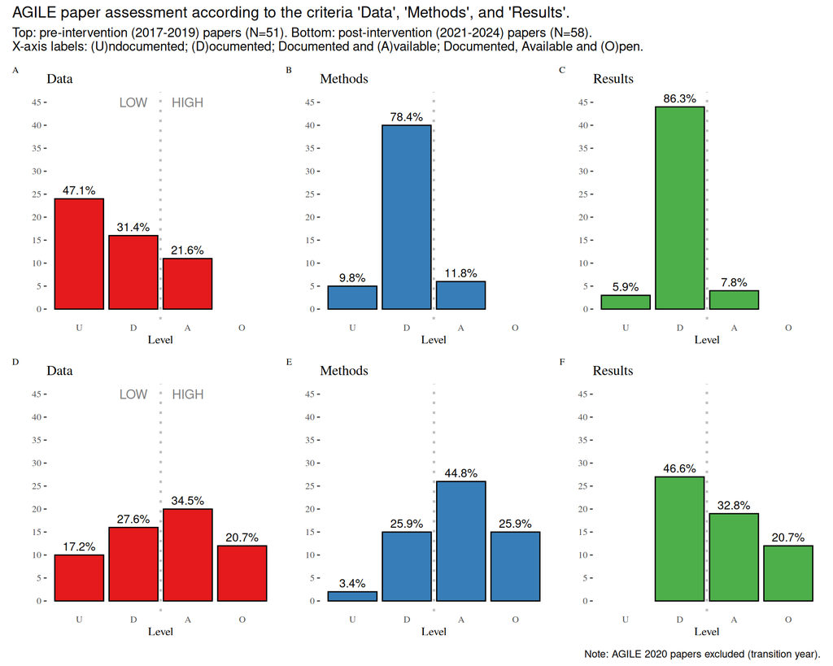

Figure 4: Evaluation of the reproducibility level of AGILE papers (pre- vs post-intervention) for each criterion: Data (A, D), Methods (B, E) and Results (C, F).

```r
(plotA + plotB + plotC) / (plotD + plotE + plotF) +
  plot_layout(widths = c(1,1,1)) +
  plot_annotation(
    title = "AGILE paper assessment according to the criteria 'Data', 'Methods', and 'Results'.",
    subtitle = stringr::str_glue("Top: pre-intervention (2017-2019) papers (N={n_papers_agile_pre}). Bottom: post-intervention (2021-2024) papers (N={n_papers_agile_post}).\n X-axis labels: (U)ndocumented; (D)ocumented; Documented and (A)vailable; Documented, Available and (O)pen."),
    caption = "Note: AGILE 2020 papers excluded (transition year).",
    tag_levels = 'A') &
  theme(plot.tag = element_text(size = 8))
```

```r
#ggplot2::ggsave(file = here::here("figs", "AGILE_pre_post.svg"),
#       width = 10, height = 7, dpi = 300)
ggplot2::ggsave(file = here::here("figs", "AGILE_pre_post.png"),
       width = 10, height = 8, dpi = 300)
```

# Transfer between the two main aggregate levels: HIGH and LOW

```r
percent_agg_level = function(df, col, lbl) {
  col <- enquo(col)

  df |>
    dplyr::count(!!col) |>
    dplyr::mutate(p = n /sum(n)) |>
    dplyr::mutate(agg_level = case_when(
      !!col %in% c("A", "O") ~ "HIGH",
      !!col %in% c("U", "D") ~ "LOW")) |>
    dplyr::group_by(agg_level) |>
    dplyr::summarise(agg_level_n = sum(n),
                     agg_level_p = sum(p)) |>
    dplyr::ungroup() |>
    dplyr::mutate(level = paste0(lbl,"-",agg_level))
}
```

## GIScience delta chart

```r
# Recompute...
papers_giscience_pre <-
  papers_giscience |>
  dplyr::filter(year < 2020) |>
  dplyr::select(-conf, -title, -consolidated_cp, -consolidated_ce, -agile_badge)

n_papers_giscience_pre = nrow(papers_giscience_pre)


papers_giscience_data_pre <- percent_agg_level(papers_giscience_pre,
                                                  col = consolidated_data,
                                                  lbl = "Input data")
papers_giscience_data_pre <-
  papers_giscience_data_pre |>
  dplyr::rename(agg_level_n_pre = "agg_level_n", agg_level_p_pre = "agg_level_p")

papers_giscience_methods_pre <- percent_agg_level(papers_giscience_pre,
                                                  col = consolidated_methods,
                                                  lbl = "Methods")
papers_giscience_methods_pre <-
  papers_giscience_methods_pre |>
  dplyr::rename(agg_level_n_pre = "agg_level_n", agg_level_p_pre = "agg_level_p")

papers_giscience_results_pre <-  percent_agg_level(papers_giscience_pre,
                                                  col = consolidated_results,
                                                  lbl = "Results")
papers_giscience_results_pre <-
  papers_giscience_results_pre |>
  dplyr::rename(agg_level_n_pre = "agg_level_n", agg_level_p_pre = "agg_level_p")

# Recompute...
papers_giscience_post <-
  papers_giscience |>
  dplyr::filter(year > 2020) |>
  dplyr::select(-conf, -title, -consolidated_cp, -consolidated_ce, -agile_badge)

n_papers_giscience_post = nrow(papers_giscience_post)


papers_giscience_data_post <- percent_agg_level(papers_giscience_post,
                                                  col = consolidated_data,
                                                  lbl = "Input data")
papers_giscience_data_post <-
  papers_giscience_data_post |>
  dplyr::rename(agg_level_n_post = "agg_level_n", agg_level_p_post = "agg_level_p")

papers_giscience_methods_post <- percent_agg_level(papers_giscience_post,
                                                  col = consolidated_methods,
                                                  lbl = "Methods")
papers_giscience_methods_post <-
  papers_giscience_methods_post |>
  dplyr::rename(agg_level_n_post = "agg_level_n", agg_level_p_post = "agg_level_p")

papers_giscience_results_post <-  percent_agg_level(papers_giscience_post,
                                                  col = consolidated_results,
                                                  lbl = "Results")
papers_giscience_results_post <-
  papers_giscience_results_post |>
  dplyr::rename(agg_level_n_post = "agg_level_n", agg_level_p_post = "agg_level_p")

# Merge all partial datasets

merged_giscience <-
  bind_rows(
    dplyr::full_join(papers_giscience_data_pre, papers_giscience_data_post, by=c("agg_level", "level")),
    dplyr::full_join(papers_giscience_methods_pre, papers_giscience_methods_post, by=c("agg_level", "level")),
    dplyr::full_join(papers_giscience_results_pre, papers_giscience_results_post, by=c("agg_level", "level"))
  )

levels_ordered = c("Input data-HIGH", "Input data-LOW", "Methods...-HIGH", "Methods...-LOW", "Results-LOW", "Results-HIGH")

# Manual trick: As there are NA values, i.e, no papers in some `level`, replaced by 0
merged_giscience <-
  merged_giscience |>
  tidyr::replace_na(list(agg_level_n_pre = 0, agg_level_p_pre = 0)) |>
  dplyr::mutate(gap_p = agg_level_p_post - agg_level_p_pre) |>
  dplyr::mutate(level = factor(level))

#merged_giscience$level <- fct_relevel(merged_giscience$level,levels_ordered)
```

```r
# Same colors as per each criteria used before
colours <- RColorBrewer::brewer.pal(length(categoryColumns), "Set1")
#colours <- c("#E41A1C", "#E41A1C", "#377EB8", "#377EB8", "#4DAF4A", "#4DAF4A")

merged_giscience %>%
  # To avoid redundancy, keep entries with HIGH level
  dplyr::filter(agg_level == "HIGH") |>
  dplyr::select(-agg_level_n_pre, -agg_level_n_post, -agg_level) |>
  ggplot2::ggplot(aes(x=gap_p, y=level)) +
  ggplot2::geom_col(aes(fill = level,
               alpha = ifelse(gap_p < 0, .4, 1)),
               show.legend = FALSE) +
  ggplot2::geom_text(
      aes(label = scales::label_percent(accuracy = 0.1)(gap_p),
          hjust = ifelse(gap_p < 0, -0.1, 1.2)),
      size = 4,
      color = "black"
    ) +

  ggplot2::geom_vline(xintercept = 0, linetype = "solid", color = "grey") + # Reference line at 0%
  #ggplot2::geom_hline(yintercept = 4.5, linetype = "dashed", color = "grey") +
  #ggplot2::geom_hline(yintercept = 2.5, linetype = "dashed", color = "grey") +

  ggplot2::scale_x_continuous(labels = scales::percent_format(accuracy = 1))+
  ggplot2::scale_fill_manual(values = colours) +
  ggplot2::labs(
    title = "GIScience papers",
    x = "Change in percentage (gap) = % post - % pre",
    y = "Criteria and levels grouped into HIGH (A,O) and LOW (U, D)") +
  ggthemes::theme_tufte(base_size = 10) +
  ggplot2::theme(plot.title = element_text(hjust = 0.5)) + # Title centered,
  ggplot2::theme(axis.ticks.y=element_blank()) -> plot_delta_giscience
```

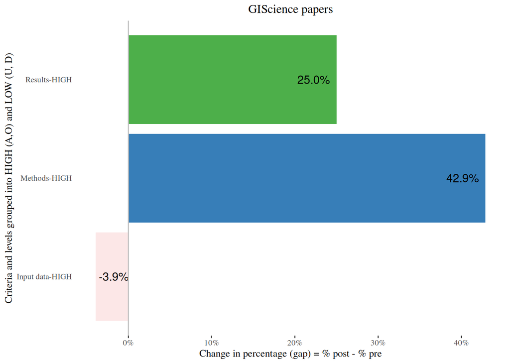

```r
plot_delta_giscience
```

## AGILE delta chart

```r
# Recompute...
papers_agile_pre <-
  papers_agile |>
  dplyr::filter(year < 2020) |>
  dplyr::select(-conf, -title, -consolidated_cp, -consolidated_ce, -agile_badge)

n_papers_agile_pre = nrow(papers_agile_pre)


papers_agile_data_pre <- percent_agg_level(papers_agile_pre,
                                                  col = consolidated_data,
                                                  lbl = "Input data")
papers_agile_data_pre <-
  papers_agile_data_pre |>
  dplyr::rename(agg_level_n_pre = "agg_level_n", agg_level_p_pre = "agg_level_p")

papers_agile_methods_pre <- percent_agg_level(papers_agile_pre,
                                                  col = consolidated_methods,
                                                  lbl = "Methods")
papers_agile_methods_pre <-
  papers_agile_methods_pre |>
  dplyr::rename(agg_level_n_pre = "agg_level_n", agg_level_p_pre = "agg_level_p")

papers_agile_results_pre <-  percent_agg_level(papers_agile_pre,
                                                  col = consolidated_results,
                                                  lbl = "Results")
papers_agile_results_pre <-
  papers_agile_results_pre |>
  dplyr::rename(agg_level_n_pre = "agg_level_n", agg_level_p_pre = "agg_level_p")

# Recompute...
papers_agile_post <-
  papers_agile |>
  dplyr::filter(year > 2020) |>
  dplyr::select(-conf, -title, -consolidated_cp, -consolidated_ce, -agile_badge)

n_papers_agile_post = nrow(papers_agile_post)


papers_agile_data_post <- percent_agg_level(papers_agile_post,
                                                  col = consolidated_data,
                                                  lbl = "Input data")
papers_agile_data_post <-
  papers_agile_data_post |>
  dplyr::rename(agg_level_n_post = "agg_level_n", agg_level_p_post = "agg_level_p")

papers_agile_methods_post <- percent_agg_level(papers_agile_post,
                                                  col = consolidated_methods,
                                                  lbl = "Methods")
papers_agile_methods_post <-
  papers_agile_methods_post |>
  dplyr::rename(agg_level_n_post = "agg_level_n", agg_level_p_post = "agg_level_p")

papers_agile_results_post <-  percent_agg_level(papers_agile_post,
                                                  col = consolidated_results,
                                                  lbl = "Results")
papers_agile_results_post <-
  papers_agile_results_post |>
  dplyr::rename(agg_level_n_post = "agg_level_n", agg_level_p_post = "agg_level_p")

# Merge all partial datasets

merged_agile <-
  bind_rows(
    dplyr::full_join(papers_agile_data_pre, papers_agile_data_post, by=c("agg_level", "level")),
    dplyr::full_join(papers_agile_methods_pre, papers_agile_methods_post, by=c("agg_level", "level")),
    dplyr::full_join(papers_agile_results_pre, papers_agile_results_post, by=c("agg_level", "level"))
  )

levels_ordered = c("Input data-HIGH", "Input data-LOW", "Methods-HIGH", "Methods-LOW", "Results-LOW", "Results-HIGH")

merged_agile <-
  merged_agile |>
  dplyr::mutate(gap_p = agg_level_p_post - agg_level_p_pre) |>
  dplyr::mutate(level = factor(level))

#merged_agile$level <- fct_relevel(merged_agile$level, levels_ordered)
```

```r
# Same colors as per each criteriaUse s
colours <- RColorBrewer::brewer.pal(length(categoryColumns), "Set1")
# colours <- c("#E41A1C", "#E41A1C", "#377EB8", "#377EB8", "#4DAF4A", "#4DAF4A")

merged_agile %>%
  # To avoid redundancy, keep entries with HIGH level
  dplyr::filter(agg_level == "HIGH") |>
  dplyr::select(-agg_level_n_pre, -agg_level_n_post, -agg_level) |>
  ggplot2::ggplot(aes(x=gap_p, y=level)) +
  ggplot2::geom_col(aes(fill = level),
               #alpha = ifelse(gap_p < 0, .4, 1.0)),
               alpha = 1.0,
               show.legend = FALSE) +
  ggplot2::geom_text(
      aes(label = scales::label_percent(accuracy = 0.1)(gap_p),
          hjust = ifelse(gap_p < 0, -0.1, 1.1)),
      size = 4,
      color = "black"
    ) +

  ggplot2::geom_vline(xintercept = 0, linetype = "solid", color = "grey") + # Reference line at 0%
  #ggplot2::geom_hline(yintercept = 4.5, linetype = "dashed", color = "grey") +
  #ggplot2::geom_hline(yintercept = 2.5, linetype = "dashed", color = "grey") +

  ggplot2::scale_x_continuous(labels = scales::percent_format(accuracy = 1))+
  ggplot2::scale_fill_manual(values = colours) +
  ggplot2::labs(
    title = "AGILE papers",
        x = "Change in percentage (gap) = % post - % pre") +
  ggthemes::theme_tufte(base_size = 10) +
  ggplot2::theme(plot.title = element_text(hjust = 0.5)) + # Title centered,
  ggplot2::theme(axis.title.y=element_blank(),
        axis.text.y=element_blank(),
        axis.ticks.y=element_blank()) -> plot_delta_agile
```

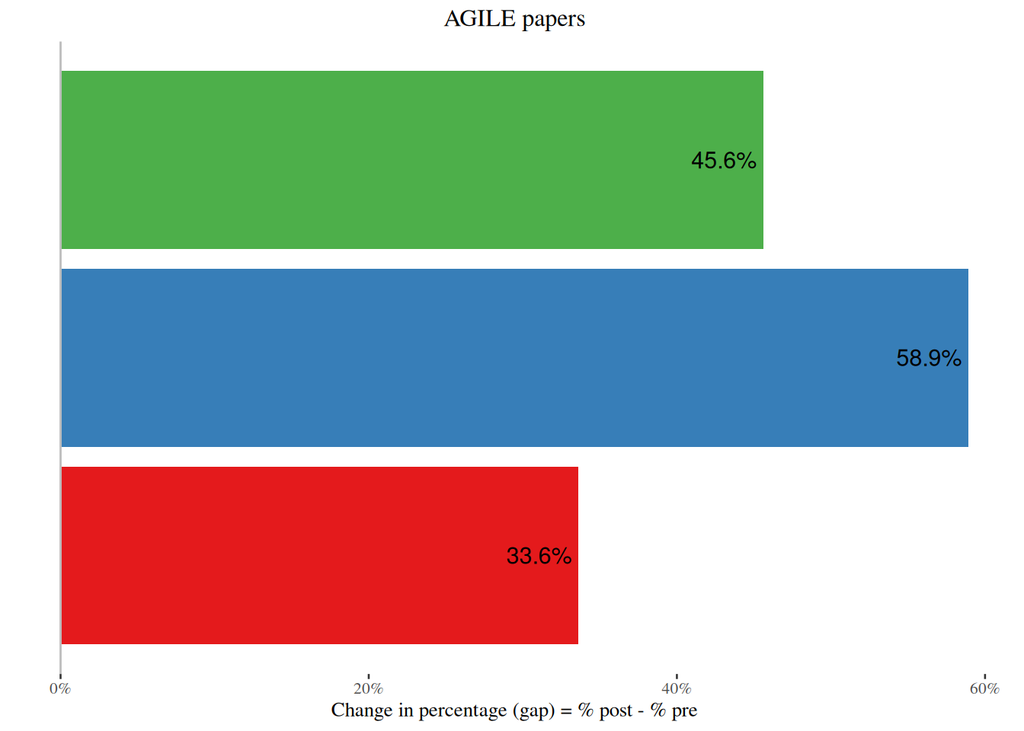

```r
plot_delta_agile
```

[output not shown]

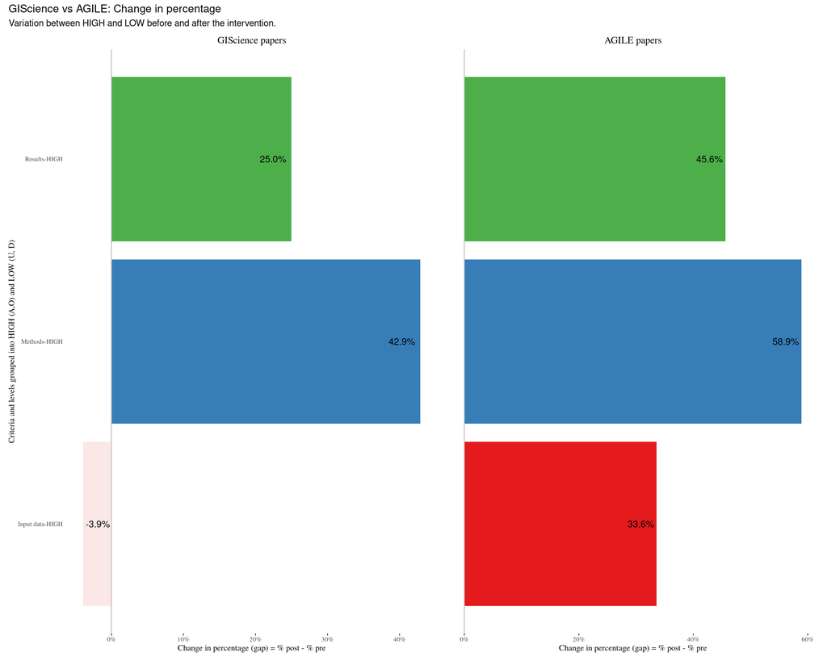

```r
(plot_delta_giscience + plot_delta_agile)  +
  plot_layout(widths = c(1,1)) +
  plot_annotation(
    title = "GIScience vs AGILE: Change in percentage",
    subtitle = "Variation between HIGH and LOW before and after the intervention.")
  theme(plot.tag = element_text(size = 10))
```

```r
#ggplot2::ggsave(file = here::here("figs", "GIScience_AGILE_delta.svg"),
#       width = 10, height = 7, dpi = 300)
ggplot2::ggsave(file = here::here("figs", "GIScience_AGILE_delta.png"),
       width = 10, height = 5, dpi = 300)
```

```r
data_tbl_absolute_change <-
  bind_rows(
    merged_giscience |>
      # To avoid redundancy, keep entries with HIGH level
      dplyr::filter(agg_level == "HIGH") |>
      dplyr::mutate(conf = "giscience") |>
      dplyr::select(conf, level, gap_p),

    merged_agile |>
      # To avoid redundancy, keep entries with HIGH level
      dplyr::filter(agg_level == "HIGH") |>
      dplyr::mutate(conf = "agile") |>
      dplyr::select(conf, level, gap_p)
  )


tbl_absolute_change <-
  data_tbl_absolute_change |>
  dplyr::mutate(conf = stringr::str_to_upper(conf)) |>
  tidyr::pivot_wider(names_from = conf, values_from = gap_p) |>
  gt::gt() |>
  gt::tab_header(
    title = "GIScience vs AGILE: Absolute change in percentage points",
    subtitle = md("Variation between *HIGH* and *LOW* before and after the intervention.")
  ) |>
  gt::cols_label(
    level = md("Aggregate level per criterion*"),
    GISCIENCE = md("*GIScience*"),
    AGILE = md("*AGILE*"),
  ) |>
  gt::cols_align(
    align = c("center"),
    columns = everything()
  ) |>
 gt::fmt_percent(
    columns = c(GISCIENCE, AGILE),
    decimals = 1
  ) |>
  gt::opt_align_table_header(align = "center")


tbl_absolute_change
```

GIScience vs AGILE: Absolute change in percentage points

Variation between *HIGH* and *LOW* before and after the intervention.

| Aggregate level per criterion* | *GIScience* | *AGILE* |
| --- | --- | --- |
| Input data-HIGH | −3.9% | 33.6% |
| Methods-HIGH | 42.9% | 58.9% |
| Results-HIGH | 25.0% | 45.6% |